# ANOVA

3/27/2018

## Wolf River

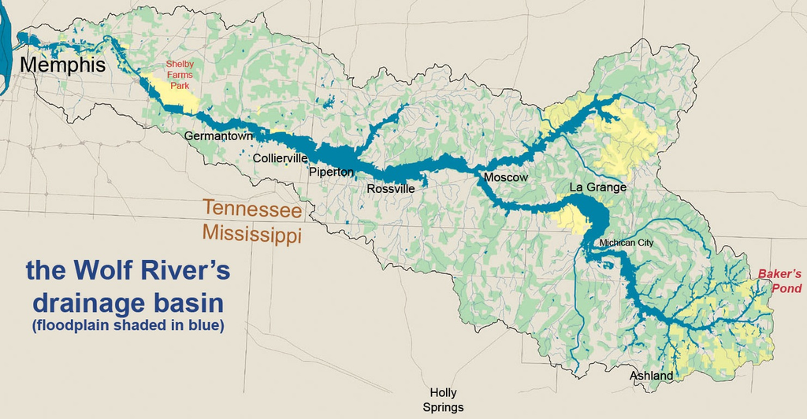

- The Wolf River in Tennessee flows past an abandoned site once used by the pesticide industry for dumping wastes, including hexachlorobenzene (HCB).
- HCB known to cause various cancers and birth defects.

## Wolf River study

- Standard method to test whether HCB is present in a river is to take samples at middepth.
- HCB is denser than water, so is it found at different concentrations at different depths?

```r
str(wolf)
```

```
## 'data.frame':    30 obs. of  3 variables:
##  $ Depth : Factor w/ 3 levels "Bottom","Middepth",..: 3 3 3 3 3 3 3 3 3 3 ...
##  $ Aldrin: num  3.08 3.58 3.81 4.31 4.35 4.4 3.67 5.17 5.17 4.35 ...
##  $ HCB   : num  3.74 4.61 4 4.67 4.87 5.12 4.52 5.29 5.74 5.48 ...
```

```r
head(wolf)
```

```
##     Depth Aldrin  HCB
## 1 Surface   3.08 3.74
## 2 Surface   3.58 4.61
## 3 Surface   3.81 4.00
## 4 Surface   4.31 4.67
## 5 Surface   4.35 4.87
## 6 Surface   4.40 5.12
```

## Wolf River data

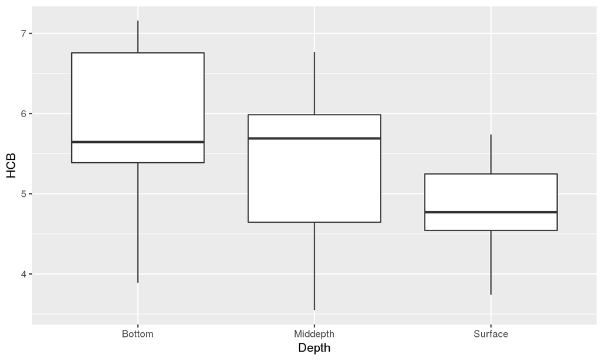

## Wolf River data

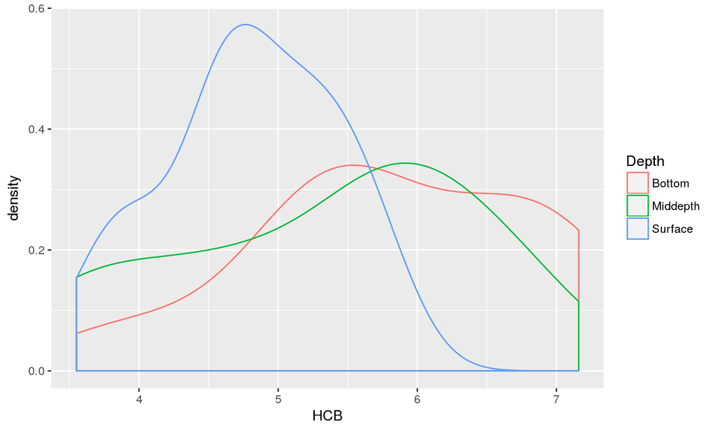

Which of the following plots shows groups with means that are *most* and *least* likely to be significantly different from each other?

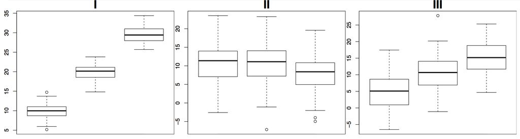

1. most: I, least: II
2. most: II, least: III
3. most: I, least: III
4. most: III, least: II

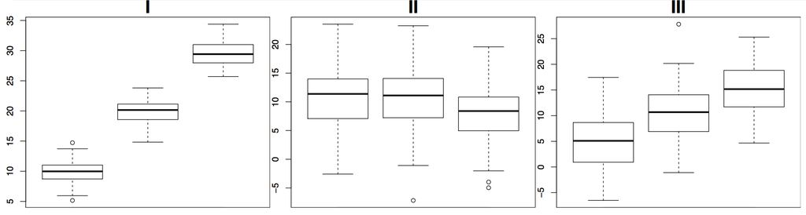

- I has a high F.
- II has a low F.
- III has a middling F.

## Wolf River data

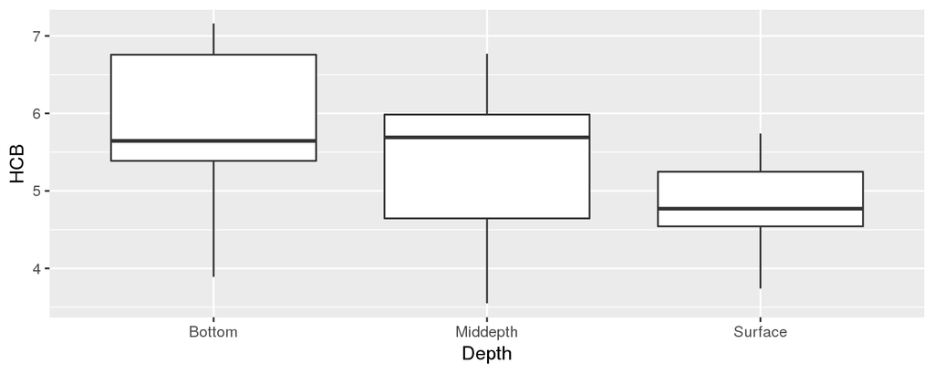

```r
f <- anova(aov(HCB ~ Depth, data = wolf))
f[, 1:4]
```

```
##           Df Sum Sq Mean Sq F value
## Depth      2   5.36   2.678    3.03
## Residuals 27  23.85   0.883
```

How big is 3.032?

## ANOVA F-test

\[ H_0: \mu_1 = \mu_2 = \ldots = \mu_k \] \[ H_A: \textrm{At least one } \mu_j \textrm{ is different} \]

We can find the distribution of the F-statistic under the null hypothesis by

- Randomization
- Mathematical approximation

## Null dist for F via Randomization

```r
wolf %>%
  specify(response = HCB, explanatory = Depth) %>%
  hypothesize(null = "independence") %>%
  generate(reps = 1000, type = "permute") %>%
  calculate(stat = "F")
```

## Null dist for F via Randomization

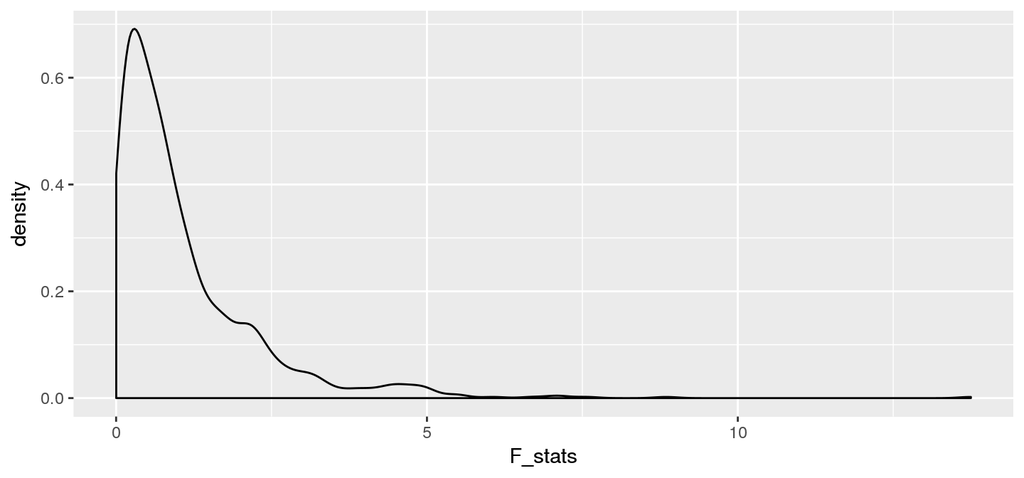

```r
mean(F_stats >= 3.032)
```

```
## [1] 0.065
```

## Null dist for F via Approximation

If:

1. Independent observations.
2. Approximate normal distributions within groups.
3. Constant variance between groups.

Then the null distribution for the \(F\) statistic under the \(H_0\) is well approximated by an F distribution with \(df_1 = k - 1\) and \(df_2 = N - k\). The p-value is represented by the upper tail.

```
## Analysis of Variance Table
##
## Response: HCB
##           Df Sum Sq Mean Sq F value Pr(>F)
## Depth      2   5.36   2.678    3.03  0.065 .
## Residuals 27  23.85   0.883
## ---
## Signif. codes:  0 '***' 0.001 '**' 0.01 '*' 0.05 '.' 0.1 ' ' 1
```

## Null dist for F via Approximation

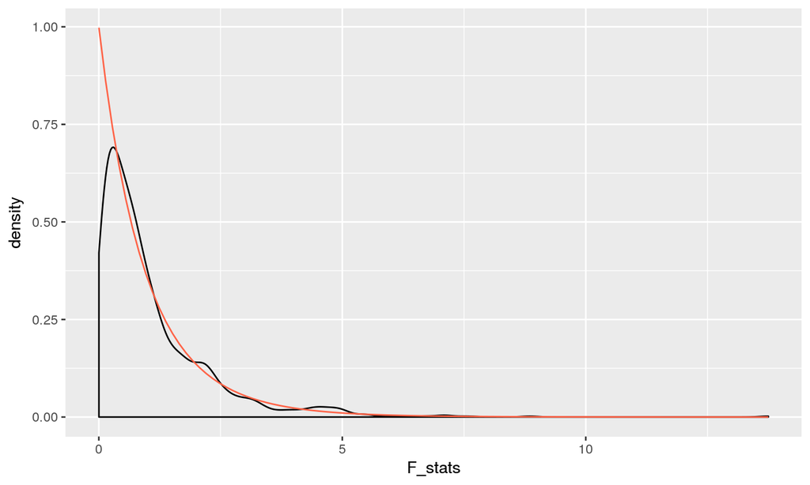

## Wolf River Conclusions

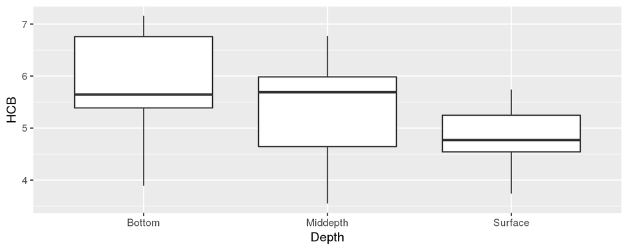